# Caracal Distribution

Grethen de Waal

2026-03-02

The urban caracal experiences significant anthropogenic challenges that impact their territories, foraging and lifespans. Caracals living in the Cape Peninsula frequently encounter humans as they forage along the urban edge.

Distribution data was taken from two sources, iNaturalist and Movebank.

### iNaturalist sightings

Read data into R using rinat package

```r
library("rinat")

inat_obs_raw <- get_inat_obs(taxon_name = "Caracal caracal",
                   bounds = c(-35, 18, -33.5, 18.5),
                   quality = "research",
                   maxresults = 500)
```

```r
library(tidyverse)
inat_obs <- inat_obs_raw %>%
  filter(coordinates_obscured == "false")
```

The data frame was converted to spatial data:

```r
library(sf)
inat_sf <- st_as_sf(
  inat_obs,
  coords = c("longitude", "latitude"),
  crs = 4326)
```

The data were plotted onto an interactive map:

```r
library(leaflet)
library(mapview)
library(leafpop)
library(move2)

sighting <- inat_sf %>%
  mutate('🔗' = paste("<b><a href='", url, "'>Link to iNat observation</a></b>"),
         '📷' = paste("<img src ='", image_url , "' height='128'>")) %>%
  rename('👤' = "user_login", captive = captive_cultivated)

mapview(sighting,
        popup = popupTable(sighting,
                           zcol = c("👤", "🔗", "📷")))
```

[interactive chart not shown]

**Figure 1** shows caracal sightings reported on [iNaturalist](https://www.inaturalist.org/observations?place_id=123155&subview=map&taxon_id=42042) in the Cape Peninsula. The map is interactive. Hovering over an observation (“sighting”) displays a number. Clicking on the number displays the user who submitted the sighting, the URL to the iNaturalist entry and the photo that goes with it.

### Movebank data

The [Movebank database](https://www.movebank.org/cms/webapp?gwt_fragment=page=studies,path=study1832666571) where [Urban Caracal Project](https://www.urbancaracal.org/) (UCP) stores its distribution data has over 57,000 observations, so a single cat was selected to map.

Read data into R

```r
ucp_csv <- read.csv("Caracal movement ecology study in Cape Town, South Africa.csv")

ucp_sf <- ucp_csv %>%
  filter(!is.na(location.long)) %>%                             # Remove missing GPS points or it won't run
  filter(individual.local.identifier == "Jasper - TMC08") %>%
  st_as_sf(coords = c("location.long", "location.lat"),
           crs = 4326)
```

Plot the Movebank data

```r
ucp_map <- leaflet() %>%
  addTiles(group = "Default") %>%
  addCircleMarkers(data = ucp_sf,
                   radius = 0.5,
                   color = "blue")

ucp_map
```

[interactive chart not shown]

**Figure 2** shows the sightings of one of the tagged UCP cats called Jasper. This map is interactive with a zoom function.

### Combined map

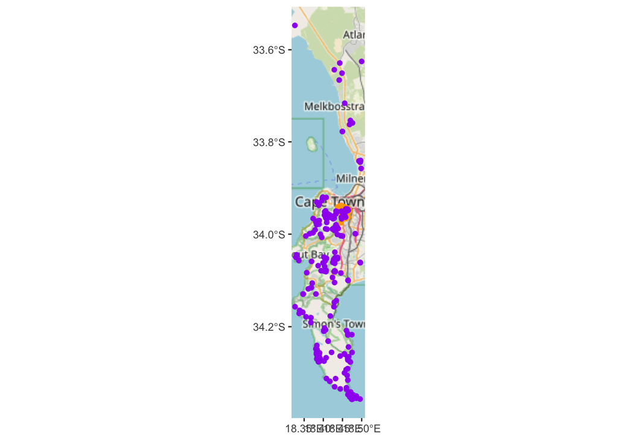

```r
library(ggspatial)

caracal_map <- ggplot() +
  annotation_map_tile(type = "osm", progress = "none") +
  geom_sf(data = ucp_sf, color = "orange") +
  geom_sf(data = inat_sf, color = "purple")

caracal_map
```

**Figure 3** shows Movebank’s data on Jasper’s movements (orange) and the iNaturalist sightings (purple) on a static map of the Cape Peninsula.